# Recommending Movies with Stochastic Gradient Descent

#### Part 5 of the MovieLens Project series

##### Previous articles

- Exploratory Data Analysis of MovieLens Dataset
- Baseline Models for Collaborative Filtering
- Recommending Movies with Similarity-Based Collaborative Filtering
- Recommending Movies with Alternating Least Squares

##### Next articles

- Comparing Collaborative Filtering Models

This is the fifth post of a project on collaborative filtering based on the MovieLens 100K dataset. The remainder of this post is straight out of a Jupyter Notebook file you can download here. You can also see it [here](https://github.com/benlindsay/movielens-analysis/blob/master/05_SGD.ipynb) on GitHub.

Previously, I showed how to do matrix factorization using Alternating Least Squares (ALS). Now we'll attempt to factorize the matrix into the same mathematical form, but we'll use a different technique to get there.

Derivation details that give us the update equations we need can be found [here](https://blog.insightdatascience.com/explicit-matrix-factorization-als-sgd-and-all-that-jazz-b00e4d9b21ea#d42b). I'll just give the start and finish here.

We start with a loss function that looks like this:

$$ L = \sum_{u,i}(r_{ui} - \hat{r}_{ui})^2 + \lambda_{b_u} \sum_u \lVert b_u \lVert^2 + \lambda_{b_i} \sum_i \lVert b_i \lVert^2 + \lambda_{x_u} \sum_u \lVert \mathbf{x}_u \lVert^2 + \lambda_{y_i} \sum_i \lVert \mathbf{y}_i \lVert^2 $$

The first term is a sum of squared errors on the predicted rating, while all the other terms are regularizing penalties on too high of values, tunable by the 4 $\lambda$ parameters. $\hat{r}_{ui}$, the predicted rating for user $u$ on item $i$, is given by

$$ \hat{r}_{ui} = \mu + b_u + b_i + \mathbf{x}_u^\top \cdot \mathbf{y}_i $$

With this setup, we can iterate over ratings, compute the gradient in the loss function for that point with respect to each parameter $b_u$, $b_i$, $\mathbf{x}_u$, and $\mathbf{y}_i$. As mentioned in the post linked above, the final update equations look like this

$$ b_u^{t+1} = b_u^{t} + \eta (e_{ui} - \lambda_{b_u})b_u \\ b_i^{t+1} = b_i^{t} + \eta (e_{ui} - \lambda_{b_i})b_i \\ \mathbf{x}_u^{t+1} = \mathbf{x}_u^{t} + \eta (e_{ui} \mathbf{y}_i - \lambda_{x_u} \mathbf{x}_u) \\ \mathbf{y}_i^{t+1} = \mathbf{y}_i^{t} + \eta (e_{ui} \mathbf{x}_u - \lambda_{y_i} \mathbf{y}_i) \\ $$

The rest of this notebook goes through writing a class to fit and predict movie ratings using SGD, then using that class to tune model parameters.

# 1. Import necessary modules and classes

Expand Code

# 2. Load the Data

Expand Code

```
First 5:
```

|  | userId | movieId | rating | timestamp |
| --- | --- | --- | --- | --- |
| 214 | 259 | 255 | 4 | 1997-09-19 23:05:10 |
| 83965 | 259 | 286 | 4 | 1997-09-19 23:05:27 |
| 43027 | 259 | 298 | 4 | 1997-09-19 23:05:54 |
| 21396 | 259 | 185 | 4 | 1997-09-19 23:06:21 |
| 82655 | 259 | 173 | 4 | 1997-09-19 23:07:23 |

```
Last 5:
```

|  | userId | movieId | rating | timestamp |
| --- | --- | --- | --- | --- |
| 46773 | 729 | 689 | 4 | 1998-04-22 19:10:38 |
| 73008 | 729 | 313 | 3 | 1998-04-22 19:10:38 |
| 46574 | 729 | 328 | 3 | 1998-04-22 19:10:38 |
| 64312 | 729 | 748 | 4 | 1998-04-22 19:10:38 |
| 79208 | 729 | 272 | 4 | 1998-04-22 19:10:38 |

# 3. Write SGDRecommender

Expand Code

# 4. Determine how many epochs are necessary

Expand Code

```
i_fold=0
i_fold=1
i_fold=2
i_fold=3
i_fold=4
```

Expand Code

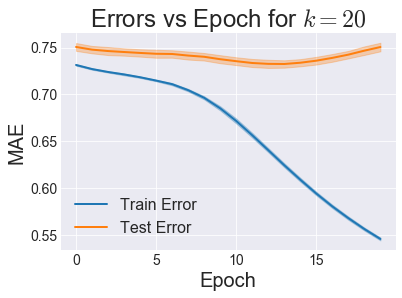

It looks like around 12 is the optimal number of iterations to run before we start overfitting, so we'll use that from here on out.

# 5. Find Optimal $k$

Expand Code

```
i_fold=0: k=1, k=5, k=10, k=20, k=50,
i_fold=1: k=1, k=5, k=10, k=20, k=50,
i_fold=2: k=1, k=5, k=10, k=20, k=50,
i_fold=3: k=1, k=5, k=10, k=20, k=50,
i_fold=4: k=1, k=5, k=10, k=20, k=50,
```

Expand Code

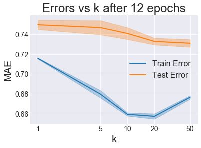

These are some very odd results that I'd want to look into given the time. I would expect training error to continually go down with increasing $k$, since that should allow for more overfitting to the training data. However, train error starts coming back up, even though test error is still going down! For now we'll just declare $k=50$ the winner since it has the lowest test error.

#### Part 5 of the MovieLens Project series

##### Previous articles

- Exploratory Data Analysis of MovieLens Dataset
- Baseline Models for Collaborative Filtering
- Recommending Movies with Similarity-Based Collaborative Filtering
- Recommending Movies with Alternating Least Squares

##### Next articles

- Comparing Collaborative Filtering Models

## Comments

[comments powered by Disqus](https://disqus.com)